# Coursera Data Science - Capstone Project

Trigram Model Word Prediction

Sascha C.

3 december 2016

Abstract

This report investigates unigram, bigram, and trigram frequencies in a Twitter, a Blog, and a News corpus. Each of the three corpora is provided by Swiftkey (download [here](https://d396qusza40orc.cloudfront.net/dsscapstone/dataset/Coursera-SwiftKey.zip)).

# 1 Tokenization

In this section, samples from each of the three corpora are tokenized into unigrams, bigrams and trigrams. First, the three corpora are read in, and samples are taken from each corpus.

```r
require(data.table)
require(ggplot2)
library(dplyr)
library(tidytext)
library(tidyr)
library(tokenizers)
#reading in corpora
twitter=scan(file="./corpora/en_US/en_US.twitter.txt",what ="character", sep="\n",encoding = "UTF-8")
blogs = scan(file="./corpora/en_US/en_US.blogs.txt",what ="character", sep="\n",encoding = "UTF-8")
news = scan(file="./corpora/en_US/en_US.news.txt",what ="character",
sep="\n",encoding = "UTF-8")
#sample function
get_sample<-function(data,sampleSize){
  sample(data,floor(sampleSize*length(data)),replace=F)
}
#taking samples
sampleSize=0.03
twitter_sample<-get_sample(twitter,sampleSize)
blogs_sample<-get_sample(blogs,sampleSize)
news_sample<-get_sample(news,sampleSize)
twitter_sample[1];blogs_sample[1];news_sample[1];
```

```
## [1] "I'm drinking lots of Schlitz and eating wings - so no problem!"
```

```
## [1] "Showdown is a cooperative learning activity in which students work first alone, and then with a team, to solve problems or answer questions on task cards. Easter Egg Showdown is a variation in which the task cards are tucked inside plastic Easter eggs. Students select an egg, open it, read t…
```

```
## [1] "According to preliminary calculations, the Dow rose 11.56, or 0.1 percent, to 10,907.42. The Dow was up as much as 44 points in morning trading."
```

The following table gives a breakdown of corpora and sample sizes:

Table 1. Size of corpora and corresponding samples; n = number of lines.

|  | Twitter | Blogs | News |
| --- | --- | --- | --- |
| **Corpus size (n)** | 2360148 | 899288 | 77259 |
| **Sample size (n)** | 70804 | 26978 | 2317 |
| **Sample size (%)** | 3 | 3 | 2.999 |

Next, the samples are tokenized into unigrams, bigrams, and trigrams.

```r
#collapsing sample vectors into single element vectors
twitter_sample<-twitter_sample%>%paste(collapse=" ")
blogs_sample<-blogs_sample%>%paste(collapse=" ")
news_sample<-news_sample%>%paste(collapse=" ")
#tokenize function
token_df<- function(text,corpus_name,ngrams){
  t=tokenize_ngrams(text, lowercase = TRUE, n = ngrams,
                    stopwords = character(), ngram_delim = " ", simplify = F)
  name_vector=rep(corpus_name,length(t[[1]]))
  d=data.table(term=t[[1]], corpus=name_vector)
}
#Creating data tables for unigrams, bigrams, trigrams
start.time <- Sys.time()
set.seed(1122)
unigramTokens<-rbind(token_df(twitter_sample,"twitter",1L),token_df(blogs_sample,"blogs",1L),token_df(news_sample,"news",1L))
bigramTokens<-rbind(token_df(twitter_sample,"twitter",2L),token_df(blogs_sample,"blogs",2L),token_df(news_sample,"news",2L))
trigramTokens<-rbind(token_df(twitter_sample,"twitter",3L),token_df(blogs_sample,"blogs",3L),token_df(news_sample,"news",3L))
end.time <- Sys.time()
time.taken <- end.time - start.time
message("Tokenization took ",time.taken," seconds.")
```

```
## Tokenization took 25.7104661464691 seconds.
```

```r
unigramTokens[1,];bigramTokens[1,];trigramTokens[1,]
```

```
##    term  corpus
## 1:  i'm twitter
```

```
##            term  corpus
## 1: i'm drinking twitter
```

```
##                 term  corpus
## 1: i'm drinking lots twitter
```

# 2 Exploratory analyses

## 2.1 Word frequency

What are the 3 most frequent words in each of the 3 corpus samples?

```r
# Calculating frequencies
dtFrequencies<-unigramTokens[,.(.N),by=.(term,corpus)]
dtFrequencies<-dtFrequencies[,total:=(sum(N)),by=corpus]
dtFrequencies<-dtFrequencies[,termFrequency:=(N/total),by=corpus]
# Getting the three most frequent unigrams for each sample
dtFrequencies%>%
  group_by(corpus) %>%
  arrange(desc(termFrequency))%>%
  top_n(3) %>% ungroup
```

```
## Source: local data table [9 x 5]
##
##    term  corpus     N   total termFrequency
##   (chr)   (chr) (int)   (int)         (dbl)
## 1   the   blogs 56145 1124482    0.04992966
## 2   and   blogs 32959 1124482    0.02931038
## 3    to   blogs 32139 1124482    0.02858116
## 4   the    news  4645   81578    0.05693937
## 5    to    news  2135   81578    0.02617127
## 6     a    news  2061   81578    0.02526416
## 7   the twitter 28086  901823    0.03114358
## 8    to twitter 23874  901823    0.02647304
## 9     i twitter 21561  901823    0.02390824
```

How are word frequencies distributed?

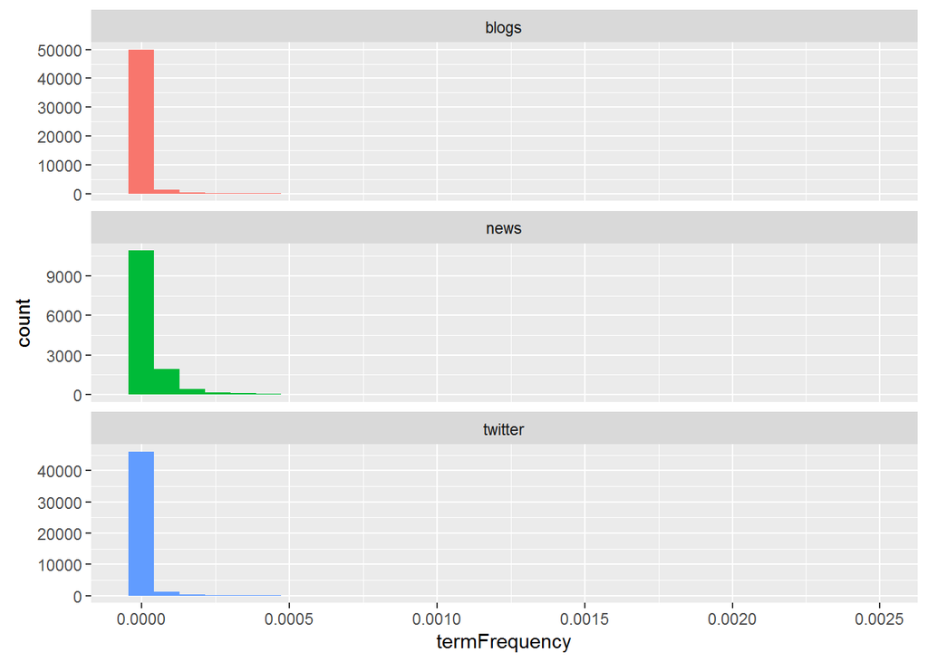

```r
# Plot histogram of frequencies
plotDtFrequencies<-ggplot(dtFrequencies, aes(termFrequency,fill=corpus)) +
  geom_histogram(show.legend = FALSE)+
  xlim(NA, 0.0025) +
  facet_wrap(~corpus, ncol = 1, scales = "free_y")
plotDtFrequencies
```

## 2.2 Inverse document frequency

What are the 10 most important words in each sample?  
To answer this, I calculated the **[inverse document frequencies](https://en.wikipedia.org/wiki/Tf-idf) (idf)** of words using the `bind_tf_idf()` function from the [tidytext R package](http://tidytextmining.com/tfidf.html). The **idf** of a word is intended to reflect how important it is to a document in a collection or corpus:

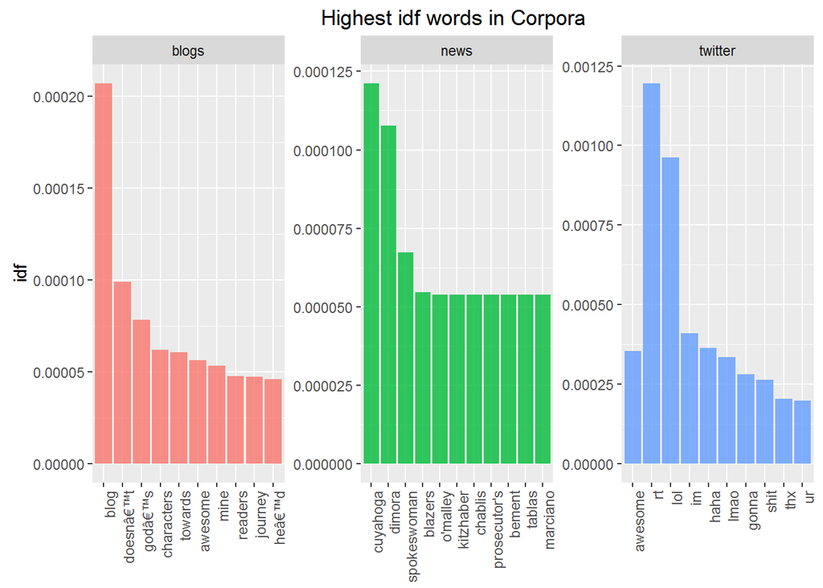

```r
dtFrequencies<- dtFrequencies %>%
  bind_tf_idf(term, corpus, N)%>%
  group_by(corpus) %>%
  arrange(desc(tf_idf))%>%
  top_n(10) %>% ungroup %>%
  mutate(term = factor(term, levels =unique(term)))
plotTfIdfFrequencies<-ggplot(dtFrequencies, aes(term, tf_idf, fill = corpus)) +
  geom_bar(alpha = 0.8, stat = "identity", show.legend = FALSE) +
  labs(title = "Highest idf words in Corpora",
       x = NULL, y = "idf") +
  facet_wrap(~corpus, ncol = 3,scales="free")+
  theme(axis.text.x = element_text(angle = 90, hjust = 1))
plotTfIdfFrequencies
```

## 2.3 Token coverage

What proportion of all unigram tokens do the the 100 most frequent unigram types cover? First, create tables:

```r
unigramFrequencies<-unigramTokens[,.(.N),by=term]
unigramFrequencies<-unigramFrequencies[order(-rank(N))]
i<-2; cumSum<-unigramFrequencies[1,N]
for(i in 2:nrow(unigramFrequencies)){cumSum=c(cumSum,cumSum[i-1]+unigramFrequencies[i,N])}
unigramFrequencies[,cumSum:=cumSum/sum(N)]
```

```
##                   term     N     cumSum
##     1:             the 88876 0.04216363
##     2:              to 58148 0.06974960
##     3:             and 48008 0.09252506
##     4:               a 47457 0.11503912
##     5:               i 44925 0.13635197
##    ---
## 79441:      vacationer     1 0.99999810
## 79442:       slopeside     1 0.99999858
## 79443: goclarendon.com     1 0.99999905
## 79444:          mandel     1 0.99999953
## 79445:        walgreen     1 1.00000000
```

Then, plot the proportion of coverage by the first 100 frequency ordered unigrams:

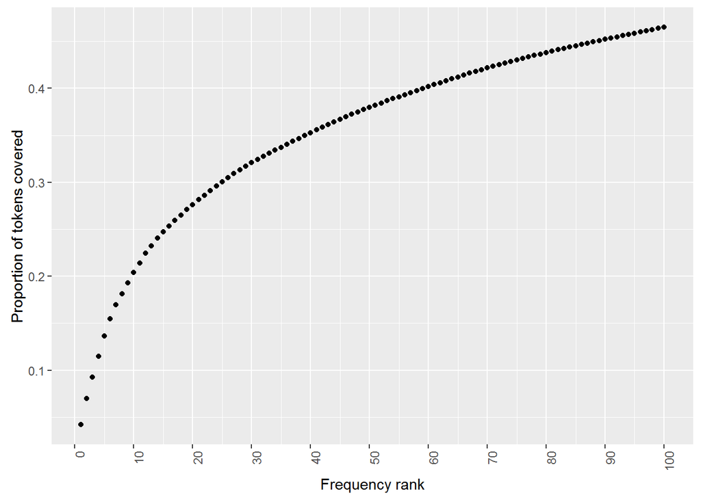

```r
# Plot proportion of coverage by frequency ordered unigrams
plotFrequencies<-ggplot(unigramFrequencies[1:100,], aes(as.integer(rownames(unigramFrequencies[1:100])), cumSum))+
  geom_point()+
  theme(axis.text.x = element_text(angle = 90, hjust = 1))+
  scale_x_continuous(breaks=seq(0,nrow(unigramFrequencies),10))+xlab("Frequency rank")+ylab("Proportion of tokens covered")
plotFrequencies
```

As can be seen in the graph, the three most frequent unigrams account for around 10% of all tokens, and the 100 most frequent unigrams for around 45%.  
How many of the most frequent unigrams do you need for a 90% coverage?

```r
message("The most frequent ", min(which(unigramFrequencies[,cumSum] > 0.9))," unigrams cover 90% of all unigram tokens.")
```

```
## The most frequent 6824 unigrams cover 90% of all unigram tokens.
```

## 2.4 Overall N-gram frequencies

What are the 10 most frequent unigrams, bigrams, and trigrams overall?

```r
start.time <- Sys.time()
unigramFrequencies<-unigramTokens[,.(.N),by=term]%>%arrange(desc(N))
unigramFrequencies[1:10,]
```

```
##     term     N
##  1:  the 88876
##  2:   to 58148
##  3:  and 48008
##  4:    a 47457
##  5:    i 44925
##  6:   of 38617
##  7:   in 31060
##  8:  you 25194
##  9:   is 24241
## 10:  for 23214
```

```r
bigramFrequencies<-bigramTokens[,.(.N),by=term]%>%arrange(desc(N))
bigramFrequencies[1:10,]
```

```
##        term    N
##  1:  of the 7641
##  2:  in the 7356
##  3:  to the 4133
##  4: for the 4131
##  5:  on the 3835
##  6:   to be 3606
##  7:  at the 2618
##  8: and the 2449
##  9:  i have 2373
## 10:   i was 2335
```

```r
trigramFrequencies<-trigramTokens[,.(.N),by=term]%>%arrange(desc(N))
trigramFrequencies[1:10,]
```

```
##                   term   N
##  1:     thanks for the 729
##  2:         one of the 674
##  3:           a lot of 596
##  4:          i want to 442
##  5:            to be a 388
##  6:        going to be 378
##  7:      thank you for 340
##  8:          i have to 335
##  9: looking forward to 322
## 10:           i have a 316
```

# 3 Still to do

1. Implementing word prediction algorith, based on stupid backoff.
2. Improve string normalization and tokenizer (the tokenizer seems to have issues with formatting)
3. Implement Shiny app